# Setting Up Doxygen

The Doxygen program is used to semi-automatically produce documentation for your code. The setup is a bit of work, but it’s worth it: it saves you a *lot* of time when writing reports, and having the documentation makes your code *much* more valuable for future use.

## Installing Doxygen

- Doxygen can be downloaded from https://www.doxygen.nl/download.html using links from the **Sources and Binaries** section on the page.
- On Windows™, run the installer.

  On MacOS™, drag Doxygen from the disk image and drop it somewhere convenient; you’ll have to tell your Mac to allow programs from non-verified sources to run or at least make an exception for this one.

  On Linux, run `sudo apt install doxygen doxypypy` in a terminal and you’re set.
- After installation, you will have a command-line program called `doxygen` and a GUI called `doxywizard.` Either can be used to create your documents, but if you use the command-line program you will need to have created or downloaded a configuration file called `Doxyfile` (more about that later).
- Check that the Doxygen Wizard GUI program can be run on your computer. On Linux, you may need to type `doxywizard` in a terminal window.

## Running Doxygen

Many people prefer to run Doxygen from a GUI. What follows are instructions for how to use the Doxygen GUI to generate documentation which can be submitted in a `.zip` file for the first couple of weeks of class and on GitHub™ during later weeks.

- On the opening page of the Doxygen Wizard GUI, specify
  - The directory in which Doxygen will run, the base directory for your project.
  - The project name, a one-line description, and a version number.
  - Optionally a logo image (use a small image so it doesn’t cover most of the screen).
  - The source code directory where your `.py` files are found, usually the `src` directory under your base directory.
  - The destination directory, usually a directory called `docs` under your base directory.

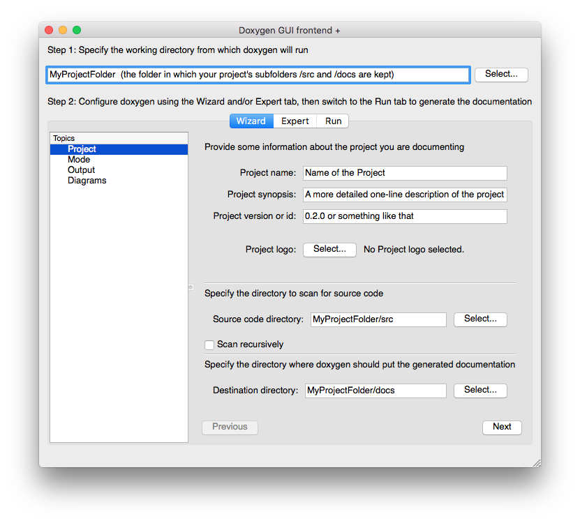

- Go to the **Output** topic and check **with navigation panel** and un-check LaTeX.

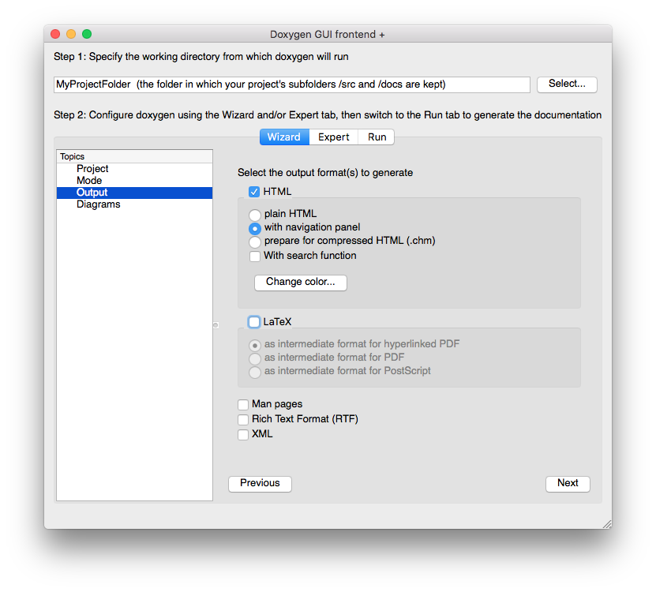

- Click the **Expert** category button and choose the **HTML** topic. In the **HTML_OUTPUT** box, select the `docs` directory you’ve created under your project base directory using the file selector button to the right of the box. *Optional:* If you’d like to use a style sheet to make your Doxygen output look nicer, enter the stylesheet file location in the **HTML_EXTRA_STYLESHEET** box.
- Choose menu item **File -> Save As…** to save the configuration file you’ve made as a file called `Doxyfile`. You can use **File -> Open…** to reload this configuration in the future.
- Now click the **Run** category button, then the **Run Doxygen** button and Doxygen should do its job. Check the text generated for errors.
- You need to check your documentation, so open the file `index.html` in your `docs` directory in a web browser, then look at the many pages of documentation which should have been generated.